# Bayesian Posterior Inference for the Gamma Model:

## Exact, ABC, Laplace, and Neural Network Approximations

This notebook investigates **posterior inference for the shape $(\alpha)$ and scale $(\beta)$ parameters of the Gamma distribution**, given observed data, and systematically compares four major Bayesian approaches:

- **"Analytical" inference:** via grid evaluation and numerical integration.
- **Approximate Bayesian Computation (ABC):** using summary statistics and rejection sampling.
- **Laplace (Normal) approximation:** via local quadratic expansion at the posterior mode (MAP).
- **Amortised neural network inference:** training a network to map data summaries to a parametric (bivariate normal) posterior, optionally regularised towards the Laplace approximation.

### Setting

- **Model:** Observed data $y_1, \ldots, y_n$ are i.i.d. draws from $\mathrm{Gamma}(\alpha, \beta)$ (shape/scale parameterisation).
- **Priors:** $\alpha \sim \mathrm{Exp}(1)$, $\beta \sim \mathrm{Exp}(1)$ (independent).
- **Task:** Recover or approximate the posterior $p(\alpha, \beta \mid y)$, and understand how the different approximation strategies perform—both qualitatively and quantitatively—given only summary statistics of the data.

### What we do

1. **Observed data generation and prior setup**
2. **Computation of the true posterior (by numerical grid)**
3. **Simulation of prior predictive datasets for ABC and neural training**
4. **Approximate Bayesian Computation (ABC)**
5. **Laplace (normal) approximation**
6. **Neural network: amortised posterior, with/without Laplace regularisation**
7. **Visual and quantitative comparison of all approaches**

```python
# ========== Imports & Seeding ==========

import numpy as np
import torch
import torch.nn as nn
import torch.optim as optim
import matplotlib.pyplot as plt
import scipy.special as sp
import random

# Set seeds for reproducibility
SEED = 0
random.seed(SEED)
np.random.seed(SEED)
torch.manual_seed(SEED)
```

```
<torch._C.Generator at 0x1bcc4b662b0>
```

### Observed Data Generation

We simulate the observed dataset by drawing 100 independent samples from a Gamma distribution with parameters $\alpha=2$ and $\beta=1$.  
This will be our observed data, and we'll assess all subsequent Bayesian inference and approximation methods on their guesses of $\alpha$ and $\beta$.  
A histogram visualises the empirical distribution of the observed values.

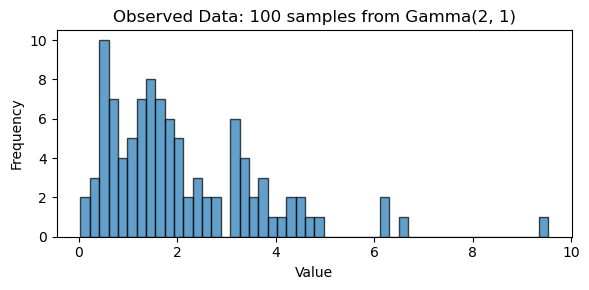

```python
# ========== Observed Data Generation ==========

num_samples = 100
gamma_shape = 2   # α (shape parameter)
gamma_scale = 1   # θ (scale parameter, so mean=α*θ)

# Draw samples
observed_data = np.random.gamma(shape=gamma_shape, scale=gamma_scale, size=num_samples)

# Optional: quick histogram to check
plt.figure(figsize=(6,3))
plt.hist(observed_data, bins=50, edgecolor='k', alpha=0.7)
plt.title('Observed Data: 100 samples from Gamma(2, 1)')
plt.xlabel('Value')
plt.ylabel('Frequency')
plt.tight_layout()
plt.show()
```

### Prior Distribution Setup

We specify independent exponential priors for both shape ($\alpha$) and scale ($\beta$) parameters: $\alpha \sim \mathrm{Exp}(1)$, $\beta \sim \mathrm{Exp}(1)$.  
For illustration, we draw samples from each prior and visualise their distributions with histograms.

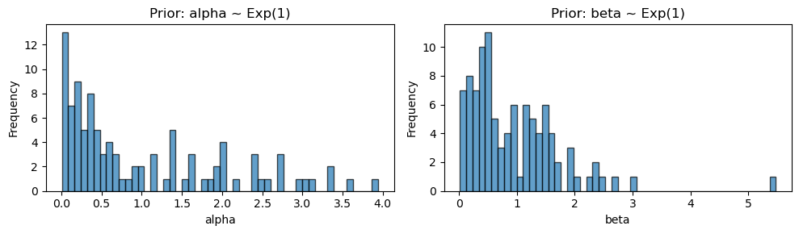

```python
# ========== Prior Distribution Setup ==========

# Independent priors: alpha ~ Exp(1), beta ~ Exp(1)
prior_alpha_scale = 1.0  # Exp(λ=1) has scale=1/λ=1
prior_beta_scale  = 1.0

# You can sample from the prior if needed (e.g., for prior predictive checks)
prior_num_samples = 100
prior_alpha_samples = np.random.exponential(scale=prior_alpha_scale, size=prior_num_samples)
prior_beta_samples  = np.random.exponential(scale=prior_beta_scale, size=prior_num_samples)

# Optional: Plot priors to check
plt.figure(figsize=(10,3))
plt.subplot(1,2,1)
plt.hist(prior_alpha_samples, bins=50, edgecolor='k', alpha=0.7)
plt.title('Prior: alpha ~ Exp(1)')
plt.xlabel('alpha')
plt.ylabel('Frequency')

plt.subplot(1,2,2)
plt.hist(prior_beta_samples, bins=50, edgecolor='k', alpha=0.7)
plt.title('Prior: beta ~ Exp(1)')
plt.xlabel('beta')
plt.ylabel('Frequency')

plt.tight_layout()
plt.show()
```

### Compute and Plot True Posterior Marginals

We compute the **exact joint posterior** for the Gamma parameters $\alpha$ and $\beta$ using a dense numerical grid and analytic expressions for the likelihood and prior.

#### **Mathematical Details**

Given observed data $y = (y_1, \ldots, y_n)$ and independent exponential priors $\alpha \sim \mathrm{Exp}(1)$, $\beta \sim \mathrm{Exp}(1)$,
the joint posterior density is (up to normalisation): $$ p(\alpha, \beta \mid y) \propto \left[\prod_{i=1}^n \mathrm{Gamma}(y_i \mid \alpha, \beta)\right] \cdot e^{-\alpha} \cdot e^{-\beta} $$ With sufficient statistics $S_1 = \sum_i \log y_i$ and $S_2 = \sum_i y_i$, the **log unnormalised posterior** is: $$ \log p(\alpha, \beta \mid y) = n\alpha \log\beta - n\log\Gamma(\alpha) + (\alpha-1) S_1 - \beta S_2 - \alpha - \beta $$

#### **Numerical Method**

- We construct a grid over plausible values of $(\alpha, \beta)$.
- Compute the (unnormalised) log posterior at each grid point, exponentiate, and normalise so the sum over the grid equals $1$.
- **Marginals** $p(\alpha \mid y)$ and $p(\beta \mid y)$ are computed by integrating (summing) the joint over the other parameter.
- Finally, we plot these marginals to visualise the exact Bayesian posterior distributions for $\alpha$ and $\beta$.

This grid approach provides a gold-standard benchmark for all subsequent approximation methods.

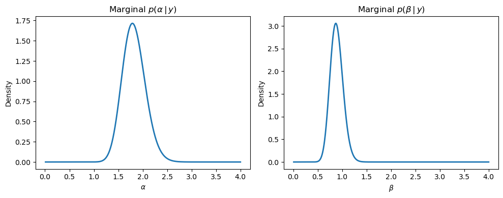

```python
# ========== Compute and Plot True Posterior Marginals ==========

# 1. Data and prior
n = len(observed_data)
sum_log_y = np.sum(np.log(observed_data))
sum_y     = np.sum(observed_data)
la = lb = 1.0  # Prior rates: alpha ~ Exp(1), beta ~ Exp(1)

# 2. Grid setup
grid_min, grid_max, n_grid = 0.01, 4.0, 1000
alpha_grid = np.linspace(grid_min, grid_max, n_grid)
beta_grid  = np.linspace(grid_min, grid_max, n_grid)
dA = alpha_grid[1] - alpha_grid[0]
dB = beta_grid[1] - beta_grid[0]
AA, BB = np.meshgrid(alpha_grid, beta_grid, indexing='ij')  # 'ij' for (alpha, beta) order

# 3. Unnormalised log posterior
log_pj = (
    n * AA * np.log(BB)
  - n * sp.gammaln(AA)
  + (AA - 1) * sum_log_y
  - BB * sum_y
  - la * AA
  - lb * BB
)
log_pj -= np.max(log_pj)  # for numerical stability

# 4. Exponentiate and normalise joint
PJ = np.exp(log_pj)
mass = PJ.sum() * dA * dB
PJ /= mass

# 5. Compute marginals by integrating over the other parameter
marginal_alpha = PJ.sum(axis=1) * dB
marginal_alpha /= marginal_alpha.sum() * dA

marginal_beta = PJ.sum(axis=0) * dA
marginal_beta /= marginal_beta.sum() * dB

# 6. Plot the marginals
plt.figure(figsize=(10, 4))

plt.subplot(1,2,1)
plt.plot(alpha_grid, marginal_alpha, lw=2)
plt.xlabel(r'$\alpha$')
plt.ylabel('Density')
plt.title(r'Marginal $p(\alpha\,|\,y)$')

plt.subplot(1,2,2)
plt.plot(beta_grid, marginal_beta, lw=2)
plt.xlabel(r'$\beta$')
plt.ylabel('Density')
plt.title(r'Marginal $p(\beta\,|\,y)$')

plt.tight_layout()
plt.show()
```

### Vectorised Prior Predictive Simulation

We generate a large table of prior-predictive samples for use in both ABC and amortised neural inference. Each row corresponds to a simulated dataset and its generating parameters.

- Draw $N$ pairs $(\alpha_j, \beta_j)$ from the prior, with both parameters exponential: $\alpha \sim \mathrm{Exp}(1)$, $\beta \sim \mathrm{Exp}(1)$.
- For each pair, simulate $M$ data points $y_{j,1}, ..., y_{j,M} \sim \mathrm{Gamma}(\alpha_j, \beta_j)$.
- Compute the sample mean and variance for each dataset.
- Store $[\alpha_j,\, \beta_j,\, \bar{y}_j,\, s_j^2]$ as one row per simulation.

This vectorised code (no explicit Python loops) is designed for fast generation of millions of such rows.

```python
# ========== Vectorised Prior Predictive Simulation (NumPy only) ==========

import numpy as np

# Parameters
N = 1_000_000  # number of (alpha, beta) prior draws
M = 100        # number of y's per (alpha, beta)

# 1. Sample alpha and beta from priors
alpha_samples = np.random.exponential(scale=1.0, size=(N, 1))  # shape (N, 1)
beta_samples  = np.random.exponential(scale=1.0, size=(N, 1))  # shape (N, 1)

# 2. Generate y: for each row, 100 samples from Gamma(alpha, beta)
y_samples = np.random.gamma(shape=alpha_samples, scale=beta_samples, size=(N, M))  # shape (N, M)

# 3. Calculate mean and variance for each row
mean_y = y_samples.mean(axis=1)
var_y  = y_samples.var(axis=1, ddof=1)

# 4. Combine results into a single NumPy array (N, 4)
prior_pred_array = np.column_stack((alpha_samples.ravel(), beta_samples.ravel(), mean_y, var_y))

# Optional: Show first 5 rows as a sanity check
print(prior_pred_array[:5])
```

```
[[0.72837758 0.69797632 0.45337115 0.265124  ]
 [0.55180212 0.5288728  0.34029768 0.16971323]
 [0.80897969 0.71386937 0.70049409 0.46838748]
 [0.33834612 0.32595493 0.10690773 0.0299519 ]
 [1.22613221 0.96836728 1.07747865 0.86500066]]
```

### Visualising Prior Predictive and ABC-Selected Summary Statistics

We compare the spread of simulated prior-predictive data summaries to the observed data, and implement the core selection step in Approximate Bayesian Computation (ABC):

#### **1. Visualising Prior Predictive Summaries**

- For each prior-predictive simulation, we plot its sample mean $\bar{y}_j$ and variance $s_j^2$ in the $(\text{mean}, \text{variance})$ plane.
- The observed data's mean and variance $(\bar{y}_{\text{obs}}, s^2_{\text{obs}})$ are marked for reference.
- This reveals whether the observed summary statistics are typical under the prior.

#### **2. ABC Selection: Closest Summaries**

- **Goal:** Identify which simulated datasets are most consistent with the observed data under the summary statistics.
- For each simulation $j$, compute the Euclidean distance: $$ d_j = \sqrt{(\bar{y}_j - \bar{y}_{\text{obs}})^2 + (s_j^2 - s^2_{\text{obs}})^2} $$
- Select the $1\%$ of simulations with the smallest $d_j$. This forms the ABC-accepted set: parameter values whose simulated data closely matches the observed summaries.
- Plot these ABC-accepted points in green, highlighting how ABC targets regions of the prior predictive distribution that resemble the observed data.

This step forms the empirical basis of ABC posterior inference: parameter values that produce data with summary statistics similar to the observed data are retained as plausible posterior samples.

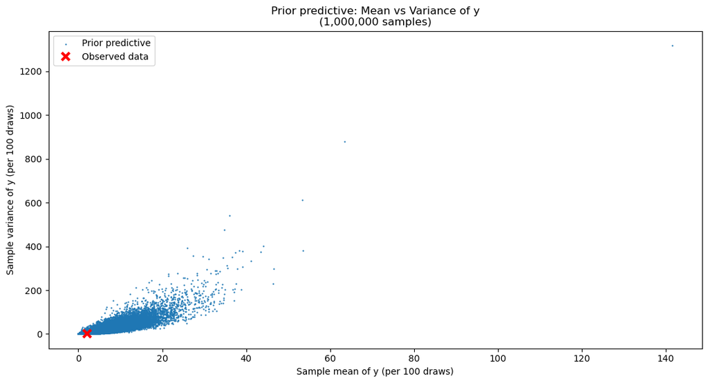

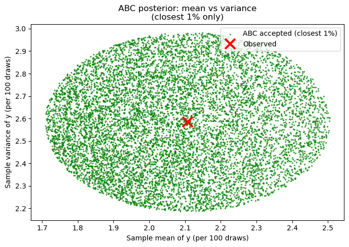

```python
import matplotlib.pyplot as plt

# Extract mean and var from simulated data
mean_y = prior_pred_array[:, 2]
var_y  = prior_pred_array[:, 3]

# Compute mean and variance of observed data
obs_mean = np.mean(observed_data)
obs_var  = np.var(observed_data, ddof=1)

plt.figure(figsize=(11, 6))
plt.scatter(mean_y, var_y, s=0.5, alpha=1, label='Prior predictive')
plt.plot(obs_mean, obs_var, 'rx', markersize=8, markeredgewidth=3, label='Observed data')

plt.xlabel("Sample mean of y (per 100 draws)")
plt.ylabel("Sample variance of y (per 100 draws)")
plt.title("Prior predictive: Mean vs Variance of y\n(1,000,000 samples)")
plt.legend()
plt.tight_layout()
plt.show()

# ========== ABC Selection: Closest 1% to Observed Summaries ==========

# Observed summaries
obs_mean = np.mean(observed_data)
obs_var  = np.var(observed_data, ddof=1)

# 1. Compute Euclidean distances to observed (mean, var)
sim_means = prior_pred_array[:, 2]
sim_vars  = prior_pred_array[:, 3]
distances = np.sqrt((sim_means - obs_mean)**2 + (sim_vars - obs_var)**2)

# 2. Find indices of closest 10%
num_keep = int(0.01 * len(distances))
closest_indices = np.argpartition(distances, num_keep)[:num_keep]

plt.figure(figsize=(7, 5))
plt.scatter(
    sim_means[closest_indices], sim_vars[closest_indices],
    s=2, alpha=0.6, color='green', label="ABC accepted (closest 1%)"
)
plt.plot(obs_mean, obs_var, 'rx', markersize=14, markeredgewidth=3, label="Observed")

plt.xlabel("Sample mean of y (per 100 draws)")
plt.ylabel("Sample variance of y (per 100 draws)")
plt.title("ABC posterior: mean vs variance\n(closest 1% only)")
plt.legend()
plt.tight_layout()
plt.show()
```

### Marginal Histograms for ABC-selected $\alpha$ and $\beta$

We visualise the ABC-approximate posterior marginals for $\alpha$ and $\beta$ by plotting histograms of the accepted parameter values (those closest to the observed summaries).  
For reference, the true posterior marginals (from grid integration) are overlaid on each plot.

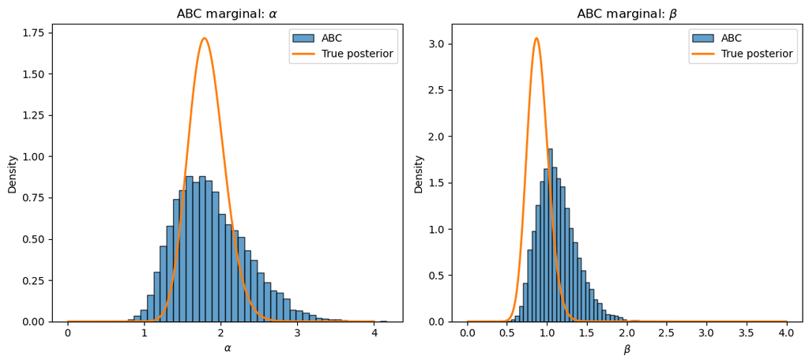

```python
selected_alphas = prior_pred_array[closest_indices, 0]
selected_betas  = prior_pred_array[closest_indices, 1]

plt.figure(figsize=(11, 5))

plt.subplot(1, 2, 1)
plt.hist(selected_alphas, bins=40, edgecolor='k', alpha=0.7, density=True, label='ABC')
plt.plot(alpha_grid, marginal_alpha, lw=2, label='True posterior')
plt.xlabel(r'$\alpha$')
plt.ylabel('Density')
plt.title(r'ABC marginal: $\alpha$')
plt.legend()

plt.subplot(1, 2, 2)
plt.hist(selected_betas, bins=40, edgecolor='k', alpha=0.7, density=True, label='ABC')
plt.plot(beta_grid, marginal_beta, lw=2, label='True posterior')
plt.xlabel(r'$\beta$')
plt.ylabel('Density')
plt.title(r'ABC marginal: $\beta$')
plt.legend()

plt.tight_layout()
plt.show()
```

### Laplace Approximation for Posterior

We approximate the joint posterior $p(\alpha, \beta \mid y)$ by a **bivariate normal distribution** centred at the posterior mode (MAP), using a local quadratic (second-order Taylor) expansion. This is known as the Laplace approximation.

#### **Mathematical Details**

- The Laplace approximation matches the true posterior near its mode, assuming the log-posterior is locally well-approximated by a quadratic function.
- **Steps:**
  1. **Find the posterior mode (MAP):** $$ (\hat{\alpha}, \hat{\beta}) = \underset{\alpha > 0,\,\beta > 0}{\arg\max}\ \log p(\alpha, \beta \mid y) $$ where $\log p(\alpha, \beta \mid y)$ combines the Gamma likelihood and exponential priors (see previous cell).
  2. **Compute the Hessian matrix $H$ at the mode:** $$ H_{ij} = \frac{\partial^2}{\partial \theta_i\,\partial \theta_j} \Big(-\log p(\alpha, \beta \mid y)\Big) \bigg|_{(\alpha, \beta) = (\hat{\alpha}, \hat{\beta})} $$
  3. **Covariance matrix:** The Laplace posterior covariance is $H^{-1}$.
  4. **Marginals:** The Laplace marginal for $\alpha$ is $\mathcal{N}(\hat{\alpha}, \Sigma_{11})$ and for $\beta$ is $\mathcal{N}(\hat{\beta}, \Sigma_{22})$, where $\Sigma = H^{-1}$.

#### **Numerical Implementation**

- We use numerical optimisation (`scipy.optimize.minimize`) to find the MAP.
- The Hessian is computed numerically by finite differences of the gradient.
- The resulting normal approximation is compared to the numerically integrated true posterior marginals for both parameters.
- Plots show the exact (numerical) marginal posterior in blue and the Laplace (normal) approximation as a dashed red curve for both $\alpha$ and $\beta$.

The Laplace approximation is fast, interpretable, and often highly accurate near the mode, especially as sample size increases, but can misrepresent skewed or multimodal posteriors.

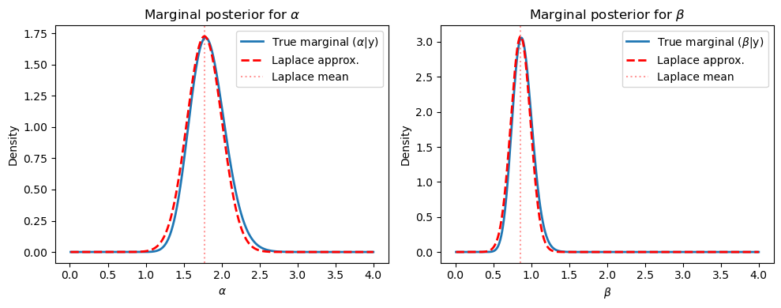

```
Laplace posterior means: alpha=1.774, beta=0.862
Laplace posterior stds:  alpha=0.231, beta=0.130
```

```python
from scipy.optimize import minimize, approx_fprime
from scipy.linalg import inv
from scipy.stats import norm

# Negative log-posterior for (alpha, beta)
def neg_log_post(params, n, sum_log_y, sum_y, la=1.0, lb=1.0):
    alpha, beta = params
    if alpha <= 0 or beta <= 0:
        return np.inf
    logp = (
        n * alpha * np.log(beta)
        - n * sp.gammaln(alpha)
        + (alpha - 1) * sum_log_y
        - beta * sum_y
        - la * alpha
        - lb * beta
    )
    return -logp

# Sufficient statistics
n = len(observed_data)
sum_log_y = np.sum(np.log(observed_data))
sum_y     = np.sum(observed_data)
la = lb = 1.0

# MAP estimate: method of moments initialisation
ybar = observed_data.mean()
yvar = observed_data.var()
init_params = np.array([ybar**2 / yvar, ybar / yvar])

result = minimize(
    neg_log_post, init_params, args=(n, sum_log_y, sum_y, la, lb),
    method='L-BFGS-B', bounds=[(1e-3, None), (1e-3, None)]
)
assert result.success, "MAP optimisation failed"
alpha_map, beta_map = result.x

# Numerical Hessian at MAP
def grad(x):
    return approx_fprime(x, lambda p: neg_log_post(p, n, sum_log_y, sum_y, la, lb), epsilon=1e-6)
def hessian(x):
    eps = 1e-5
    npar = len(x)
    hess = np.zeros((npar, npar))
    fx = grad(x)
    for i in range(npar):
        x1 = x.copy()
        x1[i] += eps
        hess[:, i] = (grad(x1) - fx) / eps
    return hess

H = hessian(result.x)
cov = inv(H)
alpha_mean, beta_mean = alpha_map, beta_map
alpha_std = np.sqrt(cov[0, 0])
beta_std  = np.sqrt(cov[1, 1])

# Plotting: Laplace vs true marginal posteriors
plt.figure(figsize=(10, 4))
for i, (grid, marginal, mean, std, label) in enumerate([
    (alpha_grid, marginal_alpha, alpha_mean, alpha_std, r'$\alpha$'),
    (beta_grid,  marginal_beta,  beta_mean,  beta_std,  r'$\beta$')
], 1):
    plt.subplot(1, 2, i)
    plt.plot(grid, marginal, lw=2, label=f'True marginal ({label}|y)')
    plt.plot(grid, norm.pdf(grid, mean, std), 'r--', lw=2, label='Laplace approx.')
    plt.axvline(mean, color='red', alpha=0.4, linestyle=':', label='Laplace mean')
    plt.xlabel(label)
    plt.ylabel('Density')
    plt.title(f'Marginal posterior for {label}')
    plt.legend()
plt.tight_layout()
plt.show()

print(f"Laplace posterior means: alpha={alpha_mean:.3f}, beta={beta_mean:.3f}")
print(f"Laplace posterior stds:  alpha={alpha_std:.3f}, beta={beta_std:.3f}")
```

### Amortised Posterior Approximation with a Neural Network

We use a neural network to learn an **amortised approximation** to the posterior $p(\alpha, \beta \mid y)$ by mapping data summaries (sample mean and variance) to the parameters of a bivariate normal distribution over $(\alpha, \beta)$.

#### **Mathematical & Implementation Details**

- **Inputs:** For each simulated dataset, the network takes as input the sample mean and variance, $[\bar{y}, s^2]$.
- **Outputs:** The network predicts:
  - Posterior mean: $\boldsymbol{\mu} = [\mu_\alpha, \mu_\beta]$
  - Posterior standard deviations: $\boldsymbol{\sigma} = [\sigma_\alpha, \sigma_\beta]$
  - Posterior correlation: $\rho$

  Together, these parameterise a bivariate normal $q(\alpha, \beta \mid \bar{y}, s^2)$.
- **Training loss:** The neural network is trained to maximise the likelihood of the true generative parameters $(\alpha, \beta)$ under its predicted normal: $$ \mathcal{L} = -\log q_\phi(\alpha, \beta \mid \bar{y}, s^2) $$ where $q_\phi$ is the predicted bivariate normal density for each training input.
- **Numerical details:**
  - `log_sigma` is clamped for numerical stability; predicted stds and correlation are mapped to valid ranges.
  - The negative log-likelihood is implemented analytically for the bivariate normal.
- **After training:**
  - The network is used to predict the approximate posterior for the observed data’s $(\bar{y}, s^2)$.
  - The resulting normal approximation is compared visually to the true posterior marginals for both $\alpha$ and $\beta$.

This amortised approach can instantly predict a full posterior normal approximation for any new dataset with similar summary statistics, providing a scalable alternative to traditional inference.

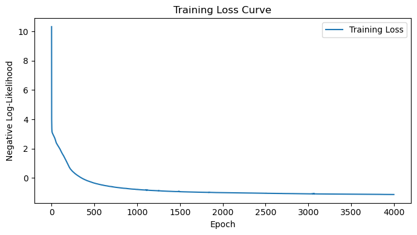

```python
import torch
import torch.nn as nn
import torch.optim as optim
import matplotlib.pyplot as plt

# 1. Prepare data as torch tensors
X = torch.tensor(prior_pred_array[:, 2:4], dtype=torch.float32)  # [mean, var]
y = torch.tensor(prior_pred_array[:, 0:2], dtype=torch.float32)  # [alpha, beta]

# 2. Neural net definition
class PosteriorNet(nn.Module):
    def __init__(self, hidden_dim=64):
        super().__init__()
        self.net = nn.Sequential(
            nn.Linear(2, hidden_dim), nn.ReLU(),
            nn.Linear(hidden_dim, hidden_dim), nn.ReLU(),
            nn.Linear(hidden_dim, hidden_dim), nn.ReLU(),
            nn.Linear(hidden_dim, 5)  # [mu_a, mu_b, log_sigma_a, log_sigma_b, atanh_rho]
        )
    def forward(self, x):
        out = self.net(x)
        mu = out[:, :2]
        log_sigma = torch.clamp(out[:, 2:4], min=-3, max=3)
        sigma = torch.exp(log_sigma)
        rho = torch.tanh(out[:, 4]).clamp(-0.98, 0.98)
        return mu, sigma, rho

# 3. Negative log-likelihood for bivariate normal
def bivariate_nll(y, mu, sigma, rho, eps=1e-6):
    x = y - mu
    sx, sy = sigma[:,0] + eps, sigma[:,1] + eps
    r = rho
    sqrt_term = torch.sqrt(1 - r**2 + eps)
    norm_const = -torch.log(2 * np.pi * sx * sy * sqrt_term)
    z = (x[:,0]/sx)**2 + (x[:,1]/sy)**2 - 2 * r * (x[:,0]/sx) * (x[:,1]/sy)
    z = z / (2 * (1 - r**2 + eps))
    logp = norm_const - z
    return -logp.mean()

# 4. Instantiate model, optimizer, and scheduler
net = PosteriorNet(hidden_dim=64)
optimizer = optim.Adam(net.parameters(), lr=5e-4)
scheduler = optim.lr_scheduler.ReduceLROnPlateau(
    optimizer, mode='min', factor=0.75, patience=15, min_lr=1e-6, verbose=True
)

n_epochs = 4000
loss_history = []

# 5. Training loop
for epoch in range(n_epochs):
    net.train()
    mu, sigma, rho = net(X)
    loss = bivariate_nll(y, mu, sigma, rho)
    optimizer.zero_grad()
    loss.backward()
    optimizer.step()
    loss_history.append(loss.item())
    scheduler.step(loss.item())
    if (epoch + 1) % 10 == 0 or epoch == 0:
        lr = optimizer.param_groups[0]['lr']
        print(f"Epoch {epoch+1}/{n_epochs}, Loss: {loss.item():.4f}, LR: {lr:.2e}")

# 6. Plot the loss curve
plt.figure(figsize=(7,4))
plt.plot(loss_history, label='Training Loss')
plt.xlabel("Epoch")
plt.ylabel("Negative Log-Likelihood")
plt.title("Training Loss Curve")
plt.legend()
plt.tight_layout()
plt.show()
```

```
NN-predicted posterior: mean alpha=1.946, mean beta=1.090
NN-predicted posterior: std alpha=0.305, std beta=0.190, correlation=-0.873
```

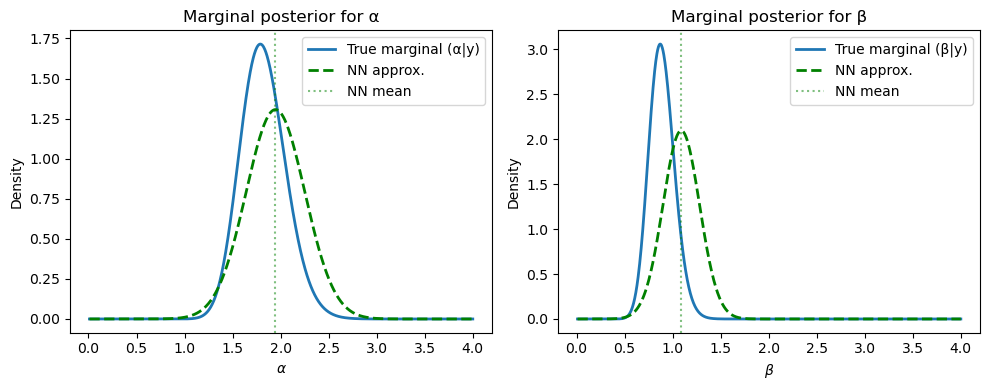

```python
from scipy.stats import norm
import matplotlib.pyplot as plt
import numpy as np

# 1. Predict posterior parameters from NN at the observed data summaries
net.eval()
with torch.no_grad():
    obs_input = torch.tensor([[np.mean(observed_data), np.var(observed_data, ddof=1)]], dtype=torch.float32)
    mu_pred, sigma_pred, rho_pred = net(obs_input)
    mu_pred = mu_pred[0].numpy()
    sigma_pred = sigma_pred[0].numpy()
    rho_pred = rho_pred[0].item()

print(f"NN-predicted posterior: mean alpha={mu_pred[0]:.3f}, mean beta={mu_pred[1]:.3f}")
print(f"NN-predicted posterior: std alpha={sigma_pred[0]:.3f}, std beta={sigma_pred[1]:.3f}, correlation={rho_pred:.3f}")

# 2. Plot the marginals: NN vs True
plt.figure(figsize=(10, 4))

# Marginal for alpha
plt.subplot(1, 2, 1)
plt.plot(alpha_grid, marginal_alpha, lw=2, label='True marginal (α|y)')
plt.plot(alpha_grid, norm.pdf(alpha_grid, mu_pred[0], sigma_pred[0]), 'g--', lw=2, label='NN approx.')
plt.axvline(mu_pred[0], color='green', alpha=0.5, linestyle=':', label='NN mean')
plt.xlabel(r'$\alpha$')
plt.ylabel('Density')
plt.title('Marginal posterior for α')
plt.legend()

# Marginal for beta
plt.subplot(1, 2, 2)
plt.plot(beta_grid, marginal_beta, lw=2, label='True marginal (β|y)')
plt.plot(beta_grid, norm.pdf(beta_grid, mu_pred[1], sigma_pred[1]), 'g--', lw=2, label='NN approx.')
plt.axvline(mu_pred[1], color='green', alpha=0.5, linestyle=':', label='NN mean')
plt.xlabel(r'$\beta$')
plt.ylabel('Density')
plt.title('Marginal posterior for β')
plt.legend()

plt.tight_layout()
plt.show()
```

### Comparing All Posterior Marginals: True, ABC, Laplace, and Neural Network

We visualise and compare the posterior marginals for $\alpha$ and $\beta$ using four approaches:

- The true posterior (via numerical grid integration),
- ABC (histogram of accepted prior samples),
- Laplace approximation (normal at the MAP),
- Neural network amortisation (normal predicted from observed summaries).

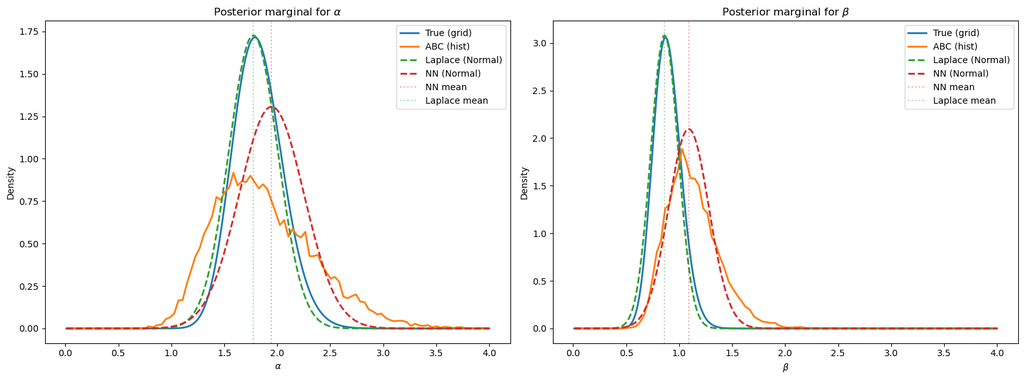

```python
import matplotlib.pyplot as plt
from scipy.stats import norm
# 1. True marginals already exist: marginal_alpha, marginal_beta, alpha_grid, beta_grid

# 2. ABC histograms (normalized)
abc_alpha_hist, alpha_bins = np.histogram(selected_alphas, bins=100, range=(alpha_grid[0], alpha_grid[-1]), density=True)
abc_beta_hist, beta_bins = np.histogram(selected_betas, bins=100, range=(beta_grid[0], beta_grid[-1]), density=True)
alpha_bin_centers = 0.5 * (alpha_bins[:-1] + alpha_bins[1:])
beta_bin_centers = 0.5 * (beta_bins[:-1] + beta_bins[1:])

# 3. Laplace and NN posterior parameters (from previous cells)
laplace_alpha_mean, laplace_beta_mean = alpha_mean, beta_mean
laplace_alpha_std, laplace_beta_std = alpha_std, beta_std
nn_alpha_mean, nn_beta_mean = mu_pred[0], mu_pred[1]
nn_alpha_std, nn_beta_std = sigma_pred[0], sigma_pred[1]

# --- Plotting ---
plt.figure(figsize=(16, 6))

# Alpha marginal
plt.subplot(1, 2, 1)
plt.plot(alpha_grid, marginal_alpha, label='True (grid)', lw=2, c='C0')
plt.plot(alpha_bin_centers, abc_alpha_hist, 'C1', lw=2, label='ABC (hist)')
plt.plot(alpha_grid, norm.pdf(alpha_grid, laplace_alpha_mean, laplace_alpha_std),
         'C2--', lw=2, label='Laplace (Normal)')
plt.plot(alpha_grid, norm.pdf(alpha_grid, nn_alpha_mean, nn_alpha_std),
         'C3--', lw=2, label='NN (Normal)')
plt.axvline(nn_alpha_mean, color='C3', alpha=0.4, linestyle=':', label='NN mean')
plt.axvline(laplace_alpha_mean, color='C2', alpha=0.4, linestyle=':', label='Laplace mean')
plt.xlabel(r'$\alpha$')
plt.ylabel('Density')
plt.title('Posterior marginal for $\\alpha$')
plt.legend()

# Beta marginal
plt.subplot(1, 2, 2)
plt.plot(beta_grid, marginal_beta, label='True (grid)', lw=2, c='C0')
plt.plot(beta_bin_centers, abc_beta_hist, 'C1', lw=2, label='ABC (hist)')
plt.plot(beta_grid, norm.pdf(beta_grid, laplace_beta_mean, laplace_beta_std),
         'C2--', lw=2, label='Laplace (Normal)')
plt.plot(beta_grid, norm.pdf(beta_grid, nn_beta_mean, nn_beta_std),
         'C3--', lw=2, label='NN (Normal)')
plt.axvline(nn_beta_mean, color='C3', alpha=0.4, linestyle=':', label='NN mean')
plt.axvline(laplace_beta_mean, color='C2', alpha=0.4, linestyle=':', label='Laplace mean')
plt.xlabel(r'$\beta$')
plt.ylabel('Density')
plt.title('Posterior marginal for $\\beta$')
plt.legend()

plt.tight_layout()
plt.show()
```

### Table Construction for MAP and Local Laplace Approximation

This cell builds a large table for supervised and Laplace-regularised neural inference. For each simulated dataset:

This ensures that only numerically stable, meaningful parameter–data combinations are retained for downstream use in neural network training and Laplace calibration.

```python
import numpy as np
import scipy.special as sp
from scipy.optimize import minimize

# Prepare arrays (assume alpha_samples, beta_samples, y_samples exist)
alpha = alpha_samples.ravel()
beta  = beta_samples.ravel()
y     = y_samples
mean_y = y.mean(axis=1)
var_y  = y.var(axis=1, ddof=1)

def neg_log_post(params, y):
    alpha, beta = params
    n = len(y)
    if alpha <= 0 or beta <= 0:
        return np.inf
    sum_log_y = np.sum(np.log(y))
    sum_y = np.sum(y)
    logp = (
        n * alpha * np.log(beta)
        - n * sp.gammaln(alpha)
        + (alpha - 1) * sum_log_y
        - beta * sum_y
        - alpha
        - beta
    )
    return -logp

def analytic_hessian(alpha, beta, n):
    h00 = -n * sp.polygamma(1, alpha)
    h11 = -n * alpha / (beta ** 2)
    h01 = h10 = -n / beta
    return h00, h01, h11

# Mask for "good" data
eps = 1e-8
good_mask = (
    (mean_y > 0) &
    (var_y > eps) &
    np.all(y > 0, axis=1)
)
alpha, beta = alpha[good_mask], beta[good_mask]
mean_y, var_y = mean_y[good_mask], var_y[good_mask]
y = y[good_mask]
N = alpha.shape[0]

# Preallocate results
alpha_hat = np.full(N, np.nan)
beta_hat  = np.full(N, np.nan)
h00 = np.full(N, np.nan)
h01 = np.full(N, np.nan)
h11 = np.full(N, np.nan)

# MAP estimation loop
for i in range(N):
    yi = y[i]
    ybar, yvar = mean_y[i], var_y[i]
    a0, b0 = ybar**2 / (yvar + eps), ybar / (yvar + eps)
    res = minimize(neg_log_post, x0=[a0, b0], args=(yi,),
                   method='L-BFGS-B', bounds=[(1e-3, None), (1e-3, None)])
    if res.success:
        a_hat, b_hat = res.x
        alpha_hat[i], beta_hat[i] = a_hat, b_hat
        n_ = len(yi)
        h00[i], h01[i], h11[i] = analytic_hessian(a_hat, b_hat, n_)

# Final mask: exclude failed fits (nan MAPs)
mask = ~np.isnan(alpha_hat)
final_table = np.column_stack([
    alpha[mask], beta[mask], mean_y[mask], var_y[mask],
    alpha_hat[mask], beta_hat[mask], h00[mask], h01[mask], h11[mask]
])
print(final_table[:5])
```

```
[[ 7.28377581e-01  6.97976325e-01  4.53371150e-01  2.65123999e-01
   7.13209859e-01  1.53917621e+00 -2.75124744e+02 -6.49698191e+01
  -3.01051401e+01]
 [ 5.51802124e-01  5.28872801e-01  3.40297682e-01  1.69713227e-01
   5.86722288e-01  1.67492481e+00 -3.77279700e+02 -5.97041727e+01
  -2.09142337e+01]
 [ 8.08979689e-01  7.13869369e-01  7.00494094e-01  4.68387484e-01
   9.85402777e-01  1.38692625e+00 -1.68073245e+02 -7.21018872e+01
  -5.12279582e+01]
 [ 3.38346119e-01  3.25954935e-01  1.06907733e-01  2.99519013e-02
   3.27764857e-01  2.80361974e+00 -1.04102837e+03 -3.56681752e+01
  -4.16988588e+00]
 [ 1.22613221e+00  9.68367283e-01  1.07747865e+00  8.65000662e-01
   9.44496921e-01  8.68519974e-01 -1.78913324e+02 -1.15138400e+02
  -1.25210551e+02]]
```

### Preparing Data and Laplace Targets for Neural Network Training

This cell prepares the input and target data for training a neural network to predict posterior distributions, and constructs analytic Laplace approximations for supervision and regularisation:

- **Extracts summary statistics and true parameters** from the final table:
  - `X_np`: sample mean and variance, to be used as neural network inputs.
  - `y_np`: generating parameters $(\alpha, \beta)$, used as "true" targets.
  - `laplace_mean_np`: MAP estimates $(\hat\alpha, \hat\beta)$, i.e., Laplace means for each dataset.
- **Computes Laplace covariance, standard deviations, and correlations**:
  - For each dataset, the negative Hessian (from previous cell) is inverted to get the local covariance matrix at the MAP.
  - Standard deviations and correlations are extracted from this covariance.
  - Numerical issues (e.g., singular Hessian) are handled by substituting safe defaults.
- **Filters out any rows with invalid Laplace approximations** (non-finite standard deviations or correlations).
- **Converts all arrays to torch tensors** for use in PyTorch-based neural network training.

The result: for each simulated dataset, we have inputs (sample mean/variance), targets (true parameters), and analytic Laplace approximations (mean, std, correlation) that can be used for supervised learning and regularisation.

```python
import torch
import numpy as np

# ===== 1. Extract from final_table =====
# Columns: [alpha, beta, mean_y, var_y, alpha_hat, beta_hat, h00, h01, h11]
# Assuming final_table is an ndarray and all rows are good.

X_np = final_table[:, [2, 3]]   # [mean_y, var_y]
y_np = final_table[:, [0, 1]]   # [alpha, beta]

# Laplace mean (MAP estimate)
laplace_mean_np = final_table[:, [4, 5]]  # [alpha_hat, beta_hat]

# Prepare Laplace covariance and invert negative Hessian per row
N = final_table.shape[0]
laplace_cov = np.empty((N, 2, 2))
laplace_std = np.empty((N, 2))
laplace_corr = np.empty(N)

for i in range(N):
    h00, h01, h11 = final_table[i, 6], final_table[i, 7], final_table[i, 8]
    H = np.array([[h00, h01], [h01, h11]])
    try:
        cov = np.linalg.inv(-H)  # Negative Hessian!
        laplace_cov[i] = cov
        laplace_std[i] = np.sqrt(np.diag(cov))
        laplace_corr[i] = cov[0, 1] / (laplace_std[i, 0] * laplace_std[i, 1] + 1e-8)
    except np.linalg.LinAlgError:
        laplace_cov[i] = np.eye(2) * 1e-6
        laplace_std[i] = 1e-3
        laplace_corr[i] = 0.0

# Mask out any nans/infs from Laplace params (shouldn’t usually occur)
good_mask = (
    np.isfinite(laplace_std).all(axis=1) &
    np.isfinite(laplace_corr)
)
if not np.all(good_mask):
    print(f"Filtered {np.sum(~good_mask)} bad Laplace approx rows.")
X_np, y_np = X_np[good_mask], y_np[good_mask]
laplace_mean_np = laplace_mean_np[good_mask]
laplace_std = laplace_std[good_mask]
laplace_corr = laplace_corr[good_mask]

# ===== 2. Convert to torch tensors =====
X = torch.from_numpy(X_np).float()
y = torch.from_numpy(y_np).float()
laplace_mean = torch.from_numpy(laplace_mean_np).float()
laplace_std = torch.from_numpy(laplace_std).float()
laplace_corr = torch.from_numpy(laplace_corr).float().unsqueeze(1)

print(f"Shapes: X={X.shape}, y={y.shape}, laplace_mean={laplace_mean.shape}, laplace_std={laplace_std.shape}, laplace_corr={laplace_corr.shape}")
```

```
Shapes: X=torch.Size([992768, 2]), y=torch.Size([992768, 2]), laplace_mean=torch.Size([992768, 2]), laplace_std=torch.Size([992768, 2]), laplace_corr=torch.Size([992768, 1])
```

### Laplace-Regularised Neural Network Training (with Stability Discussion)

Here, we train a neural network to predict a Gaussian approximation to the posterior, regularised towards the local Laplace (second-order) analytic approximation. The network takes observed summary statistics as input and predicts means, standard deviations, and correlations for $(\alpha, \beta)$. The loss is a convex combination of negative log-likelihood (NLL) for the true parameters and mean squared error (MSE) relative to the Laplace targets.

- **Training is performed for 4000 epochs.**
- The loss is:
  $$ \text{Total Loss} = (1 - \lambda)\,\text{NLL} + \lambda\,\text{Laplace MSE} $$ where $\lambda$ controls the weight of Laplace regularisation.

**Practical note:**  
Training this network is *highly unstable*. Even with Laplace regularisation, the optimisation is sensitive to initialisation, learning rate, scheduler settings, and the value of $\lambda$. Instabilities (large spikes in loss, very slow recovery, or sudden divergence) are frequent—often worse than for the plain NLL-only network. In bad initialisations, losses can explode and take hundreds or thousands of epochs to settle back down, if at all.

This makes tuning hyperparameters (especially learning rate and regularisation strength) a cumbersome and expensive process. The training run shown here, at 4000 epochs, took nearly an hour—comparable to the unregularised case, but with more fragility. This run represents a "good" case after multiple attempts.

For efficient experimentation, it is recommended to first use a smaller simulation set (e.g., $10^5$ parameter pairs instead of $10^6$) to tune these settings before scaling up to full-size training.

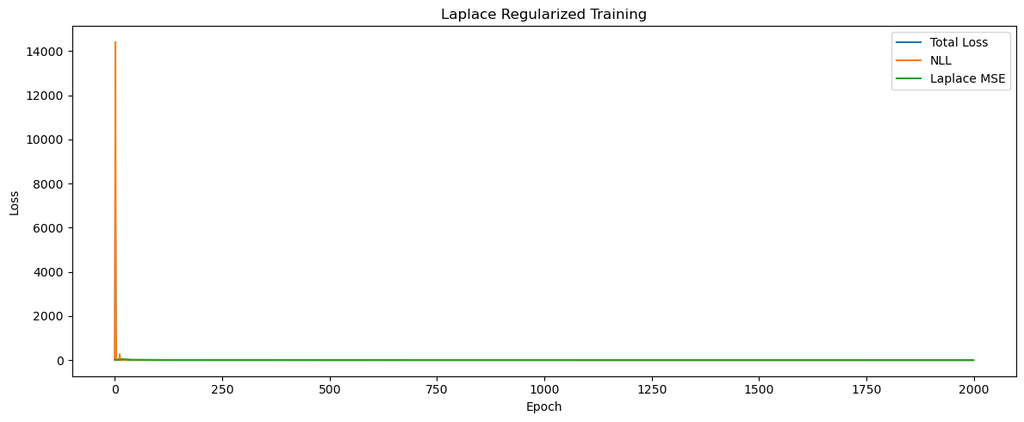

```python
import torch
import matplotlib.pyplot as plt

# --- 1. Model, optimizer, scheduler ---
laplace_reg_net = PosteriorNet(hidden_dim=128)  # Your network class must be defined
opt = torch.optim.Adam(laplace_reg_net.parameters(), lr=1e-2)
scheduler = torch.optim.lr_scheduler.ReduceLROnPlateau(opt, mode='min', factor=0.7, patience=10, verbose=True)
λ = 0.5  # Laplace regularization weight
n_epochs = 2000  # adjust as needed

nll_history, laplace_mse_history, total_history = [], [], []

# --- 2. Training loop ---
for epoch in range(n_epochs):
    laplace_reg_net.train()
    mu_pred, sigma_pred, rho_pred = laplace_reg_net(X)

    # NLL loss (user-provided function)
    nll_loss = bivariate_nll(y, mu_pred, sigma_pred, rho_pred)

    # Laplace MSE (shape correction for corr)
    mse_mean = torch.mean((mu_pred - laplace_mean) ** 2)
    mse_std  = torch.mean((sigma_pred - laplace_std) ** 2)
    mse_corr = torch.mean((rho_pred.view(-1) - laplace_corr.view(-1)) ** 2)
    laplace_mse = mse_mean + mse_std + mse_corr

    # 3. Total loss
    loss = (1 - λ) * nll_loss + λ * laplace_mse

    # 4. Optimizer step
    opt.zero_grad()
    loss.backward()
    opt.step()
    scheduler.step(loss.item())

    # 5. History
    nll_history.append(nll_loss.item())
    laplace_mse_history.append(laplace_mse.item())
    total_history.append(loss.item())

    if (epoch+1) % 1 == 0 or epoch == 0:
        print(f"Epoch {epoch+1}/{n_epochs} | LR: {opt.param_groups[0]['lr']:.2e} | NLL: {nll_loss.item():.4f} | "
              f"MSE(mean): {mse_mean.item():.4f} | MSE(std): {mse_std.item():.4f} | MSE(corr): {mse_corr.item():.4f} | "
              f"LapReg: {laplace_mse.item():.4f} | Loss: {loss.item():.4f}")

# --- 6. Plot loss curves ---
plt.figure(figsize=(12,5))
plt.plot(total_history, label='Total Loss')
plt.plot(nll_history, label='NLL')
plt.plot(laplace_mse_history, label='Laplace MSE')
plt.xlabel('Epoch')
plt.ylabel('Loss')
plt.title('Laplace Regularized Training')
plt.legend()
plt.tight_layout()
plt.show()
```

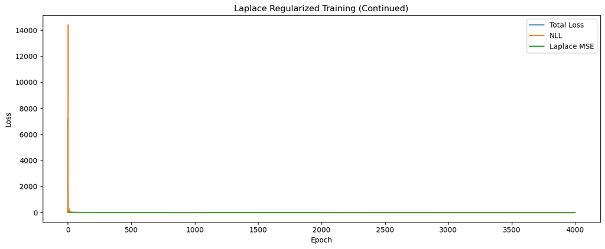

```python
# Make sure NOT to re-instantiate the model or optimizer!
# laplace_reg_net, opt, scheduler, nll_history, etc. must be the SAME objects as above!

extra_epochs = 2000  # Number of additional epochs

for epoch in range(n_epochs, n_epochs + extra_epochs):
    laplace_reg_net.train()
    mu_pred, sigma_pred, rho_pred = laplace_reg_net(X)

    nll_loss = bivariate_nll(y, mu_pred, sigma_pred, rho_pred)
    mse_mean = torch.mean((mu_pred - laplace_mean) ** 2)
    mse_std  = torch.mean((sigma_pred - laplace_std) ** 2)
    mse_corr = torch.mean((rho_pred.view(-1) - laplace_corr.view(-1)) ** 2)
    laplace_mse = mse_mean + mse_std + mse_corr

    loss = (1 - λ) * nll_loss + λ * laplace_mse

    opt.zero_grad()
    loss.backward()
    opt.step()
    scheduler.step(loss.item())

    nll_history.append(nll_loss.item())
    laplace_mse_history.append(laplace_mse.item())
    total_history.append(loss.item())

    if (epoch+1) % 1 == 0 or epoch == n_epochs or (epoch+1) % 10 == 0:
        print(f"Epoch {epoch+1}/{n_epochs+extra_epochs} | LR: {opt.param_groups[0]['lr']:.2e} | NLL: {nll_loss.item():.4f} | "
              f"MSE(mean): {mse_mean.item():.4f} | MSE(std): {mse_std.item():.4f} | MSE(corr): {mse_corr.item():.4f} | "
              f"LapReg: {laplace_mse.item():.4f} | Loss: {loss.item():.4f}")

# Re-plot including all epochs
plt.figure(figsize=(12,5))
plt.plot(total_history, label='Total Loss')
plt.plot(nll_history, label='NLL')
plt.plot(laplace_mse_history, label='Laplace MSE')
plt.xlabel('Epoch')
plt.ylabel('Loss')
plt.title('Laplace Regularized Training (Continued)')
plt.legend()
plt.tight_layout()
plt.show()
```

```
[Laplace-reg NN] mean alpha: 1.721, beta: 1.215
[Laplace-reg NN] std  alpha: 0.274, beta: 0.234, corr: -0.847
```

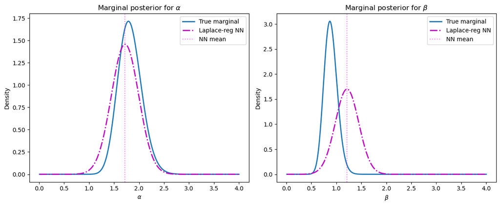

```python
import numpy as np
import matplotlib.pyplot as plt
from scipy.stats import norm
import torch

# --- Prepare observed summary input ---
obs_mean = np.mean(observed_data)
obs_var = np.var(observed_data, ddof=1)
obs_input = torch.tensor([[obs_mean, obs_var]], dtype=torch.float32)

# --- Get prediction from Laplace-regularized NN ---
laplace_reg_net.eval()
with torch.no_grad():
    mu_pred, sigma_pred, rho_pred = laplace_reg_net(obs_input)
    mu_pred = mu_pred[0].cpu().numpy()
    sigma_pred = sigma_pred[0].cpu().numpy()
    rho_pred = rho_pred[0].cpu().item()

print("[Laplace-reg NN] mean alpha: {:.3f}, beta: {:.3f}".format(mu_pred[0], mu_pred[1]))
print("[Laplace-reg NN] std  alpha: {:.3f}, beta: {:.3f}, corr: {:.3f}".format(
    sigma_pred[0], sigma_pred[1], rho_pred
))

# --- Plot marginals ---
plt.figure(figsize=(12,5))

# ---- Alpha marginal ----
plt.subplot(1,2,1)
plt.plot(alpha_grid, marginal_alpha, lw=2, color='C0', label='True marginal')
plt.plot(alpha_grid, norm.pdf(alpha_grid, mu_pred[0], sigma_pred[0]), 'm-.', lw=2, label='Laplace-reg NN')
plt.axvline(mu_pred[0], color='magenta', alpha=0.5, linestyle=':', label='NN mean')
plt.xlabel(r'$\alpha$')
plt.ylabel('Density')
plt.title('Marginal posterior for $\\alpha$')
plt.legend()

# ---- Beta marginal ----
plt.subplot(1,2,2)
plt.plot(beta_grid, marginal_beta, lw=2, color='C0', label='True marginal')
plt.plot(beta_grid, norm.pdf(beta_grid, mu_pred[1], sigma_pred[1]), 'm-.', lw=2, label='Laplace-reg NN')
plt.axvline(mu_pred[1], color='magenta', alpha=0.5, linestyle=':', label='NN mean')
plt.xlabel(r'$\beta$')
plt.ylabel('Density')
plt.title('Marginal posterior for $\\beta$')
plt.legend()

plt.tight_layout()
plt.show()
```

## Conclusion: Lessons from Comparing Posterior Approximation Methods

We compared several strategies for Bayesian posterior inference in the Gamma model, with a focus on their practical behaviour and limitations.

**Laplace and ABC: Reference Benchmarks**

Laplace and ABC serve as the classical benchmarks for posterior approximation.

- The **Laplace approximation**—a Gaussian fit at the posterior mode—looks almost perfect for this observed dataset. However, this is largely fortuitous: with a moderate sample size and reasonably central prior parameters, the true posterior happens to be close to normal. In settings with fewer data or more extreme priors, the Laplace method can easily misrepresent skewness, multimodality, or heavy tails. Thus, its success here should not be overinterpreted as a general feature of the method.
- **ABC** provides a flexible, simulation-based empirical posterior. Its accuracy is fundamentally limited by the informativeness and sufficiency of the summary statistics used, as well as by the simulation budget. In this case, using $(\bar{y}, s^2)$ is often enough to localise the posterior but still results in some bias and noisiness, especially in the tails.

**Laplace-Regularised Neural Network: The Limits of Regularisation**

Adding Laplace regularisation (i.e., penalising the NN’s parameters for deviating from the analytic Laplace approximation for each simulated dataset) was intended to make the neural approximation sharper and more locally correct. However, this can only help if the Laplace approximations seen during training are *similar* to the Laplace approximation for the observed data. In reality, the wide exponential priors for $\alpha$ and $\beta$ produce many training examples with strongly skewed, poorly-behaved, or near-degenerate Laplace approximations. The network is thus pulled in many incompatible directions: minimising both NLL (for the true parameters) and MSE (for the Laplace fit) cannot be achieved simultaneously across all the training data. The result is a flatter loss surface and difficulty in achieving convergence to a truly sharp, well-calibrated posterior for the observed dataset.

**General Lessons**

- The Laplace approximation can be an excellent benchmark, but its accuracy should always be checked against gold-standard or empirical posteriors—its success here is due to the specifics of the data and prior.
- ABC remains a flexible nonparametric tool, but is only as good as the summaries and simulation resources permit.
- Amortised neural networks, when limited to simple parametric output (like a single Gaussian), will smooth over genuinely non-Gaussian features and struggle to calibrate sharpness when training data is highly variable.
- Laplace regularisation can stabilise and “sharpen” neural approximations, but only when the simulated local Laplace posteriors genuinely resemble the region of interest. If the simulated prior is much wider or more varied than the actual observed-data posterior, regularisation alone cannot fix this mismatch.
- **For real-world problems where the posterior is not nearly normal, more adaptive training strategies may be needed for reliable amortised inference.**